# Introduction

September 2021

## Introduction

### R and RStudio

## Design of the R system

- R system is divided into 2 conceptual parts –
  - The “base” R system that you download from CRAN https://cran.r-project.org/
  - Everything else.
- The “base” package contains the most fundamental functions used to run R.
- The other packages can be downloaded and installed as per user requirements; for eg.`AER` package is required for econometrics.

## R-console

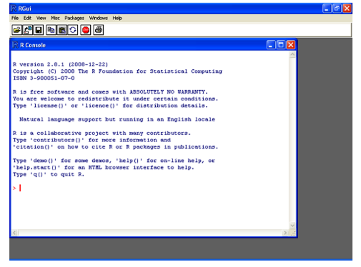

R console

## RStudio

[figure not shown]

RStudio

## RStudio

- R Studio Integrated Development Environment (IDE) is a powerful and productive user interface for R.
- Like R, it is free and multi-platform. It can be downloaded from https://www.rstudio.com/
- RStudio is a separate open-source project that brings many powerful coding tools together into an intuitive, easy-to-learn interface.
- The RStudio program can be run on the desktop or through a web browser.
- The desktop version is available for Windows, Mac OS X, and Linux platforms

## Packages in R

- A package is a related set of functions, help files, and data files that have been bundled together.
- For example, the `stats` package contains functions for doing statistical analysis. Some packages are included in R, other packages are available from public package repositories. You can also make your own packages!
- Visit the [CRAN webpage](https://cran.r-project.org/) for details on contributed packages.

## R Commands and Case Sensitivity

- Technically R is an ‘expression language’ and is case sensitive, so `A` and `a` are different symbols and would refer to different variables.
- Commands are separated either by a new-line or a semi colon (`;`).
- Comments can be put almost anywhere starting with a `#`.
- If a command is not complete at the end of a line, R will give a different prompt, by default `+` on second and subsequent lines and continue to read input until the command is syntactically complete.

## The R-language

### Basic Concepts

## The assignment operator

- `<-` is called the assignment operator, read as ‘gets’.

```r
# assign the value 1 to a.
# a gets the value 1
a <- 1
a
```

```
## [1] 1
```

```r
a <- 1 + 2
a
```

```
## [1] 3
```

## Objects

- The entries that R creates and manipulates are known as ‘objects’ (more on this later).
- During an R session objects are created and stored by name.
- The R command `objects()` can be used to display the names of the objects that are currently stored within R.
- The collection of objects currently stored is called the ‘workspace’.
- To remove objects the function `rm()` is available

```r
objects(); a <- 1+2; x
objects()
rm(x); objects()
```

## R has 5 basic/atomic classes of objects

- character: `"Hello"`
- numeric(real numbers/decimal numbers): `c(1,2.36)`.
- integer: `10L`
- complex :`2+4i`
- logical: `TRUE/FALSE`.
- There are other *higher* classes of objects like the `vector`, `matrix`, `dataframe`, `list`, `tibble`, `lm` etc (we shall discuss them later).
- `Inf` is a special number.

```r
1/Inf
```

```
## [1] 0
```

```r
Inf/Inf
```

```
## [1] NaN
```

- `NaN` (Not A Number) is a value that represents an undefined value `NaN` may represent missing values as well.

Objects in R have attributes like `names()`, `length()`, and `class()`, `dimnames()` (for a matrix, array or data frame).

```r
a1 <- 12; class(a1); length(a1)
```

```
## [1] "numeric"
```

```
## [1] 1
```

```r
names(a1) <- 'Number'; names(a1)
```

```
## [1] "Number"
```

You can name an object in R almost anything you want, but there are a few rules.

- First, a name cannot start with a number.
- Second, a name cannot use some special symbols,like `^`, `!`, `$`, `@`, `+`, `-`, `/`, or `*`.

## Working directory/ Projects

- To check the location of your working directory, use `getwd()`and to set a specific folder as your working directory use `setwd("file path")`. [Demo]
- Projects [Demo]

## The *pass-by-value* and *pass-by-reference* in R

By default, R uses “pass-by-value” paradigm. Consider the following example;

```r
x <- 1:10
x*2
x
# or consider
y <- x
x*3
y
```

## Coercion

1. Implicit Coercion
2. Explicit Coercion

Implicit Coercion occurs when we try to combine objects of two or more different classes. The ordering is roughly **LINCL** i.e `logical < integer < numeric < complex < character<list`.

```r
x <- c(1.7, "a"); class(x)
```

```
## [1] "character"
```

```r
y <- c(TRUE, 2);class(y)
```

```
## [1] "numeric"
```

```r
z <- c("a", TRUE);class(z)
```

```
## [1] "character"
```

We can explicitly coerce objects by using `as.*()` functions.

```r
x <- c(0,1,2,3,4,5,6)
class(x)
```

```
## [1] "numeric"
```

```r
as.character(x)
```

```
## [1] "0" "1" "2" "3" "4" "5" "6"
```

```r
as.complex(x)
```

```
## [1] 0+0i 1+0i 2+0i 3+0i 4+0i 5+0i 6+0i
```

```r
as.logical(x)
```

```
## [1] FALSE  TRUE  TRUE  TRUE  TRUE  TRUE  TRUE
```

Nonsensical coercion result in `NA`s. `NA` stands for Not Available.

```r
x <- c("my", "name ", "is", "khan!")
as.numeric(x)
```

```
## [1] NA NA NA NA
```

```r
as.complex(x)
```

```
## [1] NA NA NA NA
```

```r
as.logical(x)
```

```
## [1] NA NA NA NA
```

## Your turn

- Create an integer vector that contains numbers 1 to 5 and assign it to `n`.
- Check the class of `n` and convert it to a character vector. Call it `n_c`.

## Operations on Matrices

Matrices are vectors with `dimension()` attribute.

```r
m <- matrix(1:10, nrow = 2, ncol = 5)
m
```

```
##      [,1] [,2] [,3] [,4] [,5]
## [1,]    1    3    5    7    9
## [2,]    2    4    6    8   10
```

```r
dim(m)
```

```
## [1] 2 5
```

```r
length(m)
```

```
## [1] 10
```

```r
class(m)
```

```
## [1] "matrix" "array"
```

## Subsetting a matrix

Subsetting a matrix with `[` will subset objects of the same class

```r
x <- matrix(1:10, 2, 5); x
x[1,2]
x[2,5]
x[,2]
x[2,]
x[,1:3] # subset the first 3 columns of the matrix
x[,c(2,4)] # subset the second and fourth columns
x[1,c(2,4)] # subset the 1st row and second + fourth columns
diag(x) # this works only for a square matrix
t(x) # matrix transpose
```

## Your turn

- Create a 10X6 matrix with numbers between -30 and 30 (excluding 0). (Hint: Use vector subsetting.)
  - Extract the first and second elements from the fourth row.
  - Extract the second and fifth elements from the second row

## Factors

- Factors represent categorical data.
- Factors can be ordered or unordered.
- Factors can be thought as integer vector with labels, like 1 means ‘low’, 2 means ‘high’, 3 means ‘very high’.
- Example data set

  | Names | Gender | Month.Birth |
  | --- | --- | --- |
  | Kunal | Male | January |
  | Ben | Male | March |
  | Kritika | Female | March |
  | Reena | Female | December |
  | Narendra | Male | October |
  | Smriti | Female | October |

We can create factors using the information in the previous table:

```r
(Names <- c("Kunal", "Ben", "Kritika", "Reena", "Narendra", "Smriti"))
(Gender <- factor(c("Male", "Male", "Female", "Female", "Male", "Female")))
(Month.Birth <- factor(c("January", "March", "March", "December", "October", "October")))
(Month.Birth <- factor(c("January", "March", "March", "December", "October", "October"), levels = c("January", "March", "October", "December")))
```

## Extraction and subsetting

| Names | Gender | Month.Birth |
| --- | --- | --- |
| Kunal | Male | January |
| Ben | Male | March |
| Kritika | Female | March |
| Reena | Female | December |
| Narendra | Male | October |
| Smriti | Female | October |

- Which month was Smriti born in?

```r
Month.Birth[Names == "Smriti"]
```

[output not shown]

## Extraction and subsetting

| Names | Gender | Month.Birth |
| --- | --- | --- |
| Kunal | Male | January |
| Ben | Male | March |
| Kritika | Female | March |
| Reena | Female | December |
| Narendra | Male | October |
| Smriti | Female | October |

- Which boy was born in March?

```r
Names[Gender == "Male" & Month.Birth == "March"]
```

```
## [1] "Ben"
```

## Releveling a factor

```r
(levels(Month.Birth) <- c(1, 3, 10, 12))
```

```
## [1]  1  3 10 12
```

```r
(levels(Gender) <- c(0, 1)) # 0 indicates female
```

```
## [1] 0 1
```

## Defining and Ordering levels

- Performance ratings example

```r
m <- c("Poor", "Good", "Better")
rate <- factor(m)

(rate <- factor(m, ordered = TRUE,
                levels = m))
```

```
## [1] Poor   Good   Better
## Levels: Poor < Good < Better
```

## Defining and Ordering levels

- LIKERT scale example

```r
s <- 1:5
rating <- factor(s)

(rating <- factor(s, ordered = TRUE,
                levels = s))
```

```
## [1] 1 2 3 4 5
## Levels: 1 < 2 < 3 < 4 < 5
```

## Your turn

The Indian government consists of the political parties **BJP**, **INC**, **CPI**, **TMC** and other parties grouped under **Others** category. Suppose you asked 20 Indians which of these they identified most with and obtained the following data:

- There were 12 males and 8 females; the individuals numbered 1, 5-7, 12, and 14-16 were females.
- The individuals numbered 1,4,12,15,16 and 19 identified with *BJP*; no one identified with *CPI*, the individuals numbered 6,9 and 11 identified with *INC*, 10 and 20 identified with *Others*, and the rest with *TMC*.

a.Use your knowledge of vectors (for example, subsetting and overwriting) to create two character vectors: **sex** with entries “M” (male) and “F” (female) and **party** with entries “BJP”, “INC”, “CPI”, “TMC”, and “Others”. Make sure the entries are placed in the correct positions as outlined earlier.

b.Create two different factor vectors based on **sex** and **party**. Does it make any sense to use `ordered=TRUE` in either case? How has R appeared to arrange the levels?

c.Use factor subsetting to do the following: i. Return the factor vector of chosen parties for only the male participants. ii. Return the factor vector of genders for those who chose BJP.

d.Another six people joined the survey, with the results **c(“BJP”,“INC”,“INC”,“CPM”,“TMC”,“BJP”)** for the preferred party and **c(“M”,“M”,“F”,“F”,“F”,“M”)** as their gender. Combine these results with the original factors from (b).

## Data frames

- Data frames are used to store tabular data.
- Data frames have an advantage over matrices in that they can store objects of different classes.

```r
mydata <- data.frame(Name =   c("Kunal", "Ben", "Kritika", "Reena", "Narendra", "Smriti"),
Gender = factor(c("M", "M", "F", "F", "M", "F"), levels = c("M", "F")),
Age = c(20, 18, 30, 24, 24, 27))
mydata
```

```
##       Name Gender Age
## 1    Kunal      M  20
## 2      Ben      M  18
## 3  Kritika      F  30
## 4    Reena      F  24
## 5 Narendra      M  24
## 6   Smriti      F  27
```

- Subsetting

```r
mydata$Name
```

```
## [1] "Kunal"    "Ben"      "Kritika"  "Reena"    "Narendra" "Smriti"
```

```r
mydata[,c("Name", "Age")]
```

```
##       Name Age
## 1    Kunal  20
## 2      Ben  18
## 3  Kritika  30
## 4    Reena  24
## 5 Narendra  24
## 6   Smriti  27
```

```r
mydata[,c(1,3)]
```

```
##       Name Age
## 1    Kunal  20
## 2      Ben  18
## 3  Kritika  30
## 4    Reena  24
## 5 Narendra  24
## 6   Smriti  27
```

## Tibble

- Tibbles are data frames tweaked to work better in the `tidyverse`.
- It’s possible for a tibble to have column names that are not valid R variable names, aka non-syntactic names.

```r
tibble(
  `:)` = "smile",
  ` ` = "space",
  `2000` = "number"
)
```

```
## # A tibble: 1 x 3
##   `:)`  ` `   `2000`
##   <chr> <chr> <chr>
## 1 smile space number
```

- Another way to create a tibble is with `tribble()`, short for t**r**ansposed tibble.

```r
tribble(
  ~x, ~y, ~z,
  "a", 2, 3.6,
  "b", 1, 8.5
)
```

```
## # A tibble: 2 x 3
##   x         y     z
##   <chr> <dbl> <dbl>
## 1 a         2   3.6
## 2 b         1   8.5
```

## Printing large datasets

```r
library(AER); data("Journals")
Journals
```

```
##                                                            title
## APEL                           Asian-Pacific Economic Literature
## SAJoEH                 South African Journal of Economic History
## CE                                       Computational Economics
## MEPiTE       MOCT-MOST Economic Policy in Transitional Economics
## JoSE                                  Journal of Socio-Economics
## LabEc                                           Labour Economics
## EDE                        Environment and Development Economics
## RoRPE                      Review of Radical Political Economics
## EoP                                        Economics of Planning
## Mt                                                Metroeconomica
## JoCP                                  Journal of Consumer Policy
## REE                                        Real Estate Economics
## DPR                                    Development Policy Review
## MaDE                                Managerial and Decision Econ
## JoEF                                Journal of Empirical Finance
## JoEMS               International Journal of Finance & Economics
## JoE&MS                Journal of Economics & Management Strategy
## AEJ                                    Atlantic Economic Journal
## EDQ                               Economic Development Quarterly
## CER                                        China Economic Review
## IEP                             Information Economics and Policy
## AEP                                   Australian Economic Papers
## JWE                                  Japan and the World Economy
## JoES                                 Journal of Economic Surveys
## IME                           Insurance  Mathematics & Economics
## DE                                                  De Economist
## RoSE                                    Review of Social Economy
## BP                                              Brookings Papers
## PiRS                                  Papers in Regional Science
## JoPE                             Journal of Population Economics
## FS                                       Finance and Stochastics
## IO                                    International Organization
## CPP                                       Canadian Public Policy
## DvE                                         Developing Economies
## JoHoEc                              Journal of Housing Economics
## JoEB                             Journal of Economics & Business
## JoEvEc                         Journal of Evolutionary Economics
## EmpEc                                        Empirical Economics
## ER                                           Econometric Reviews
```

[output cut: 488 more lines]

```
## JoMonEc          1975  186          Macroeconomics
## MngtSc           1954  558      Management Science
## RoE&S            1919  523                 General
## RoES             1933  325                 General
## JoE              1973  129            Econometrics
## JoET             1969  165                  Theory
## EJ               1890  531                 General
## JoFE             1974  231                 Finance
## JoCR             1974  536      Consumer Economics
## JASA             1971  487            Econometrics
## JoFi             1945  799                 Finance
## QJoE             1886  660                 General
## JoPolEc          1892  737                 General
## Ecnmt            1932  346                 General
## AER              1911 1098                 General
```

```r
as_tibble(Journals)
```

```
## # A tibble: 180 x 10
##    title publisher society price pages charpp citations foundingyear  subs field
##    <chr> <fct>     <fct>   <int> <int>  <int>     <int>        <int> <int> <fct>
##  1 Asia~ Blackwell no        123   440   3822        21         1986    14 Gene~
##  2 Sout~ So Afr e~ no         20   309   1782        22         1986    59 Econ~
##  3 Comp~ Kluwer    no        443   567   2924        22         1987    17 Spec~
##  4 MOCT~ Kluwer    no        276   520   3234        22         1991     2 Area~
##  5 Jour~ Elsevier  no        295   791   3024        24         1972    96 Inte~
##  6 Labo~ Elsevier  no        344   609   2967        24         1994    15 Labor
##  7 Envi~ Cambridg~ no         90   602   3185        24         1995    14 Deve~
##  8 Revi~ Elsevier  no        242   665   2688        27         1968   202 Spec~
##  9 Econ~ Kluwer    no        226   243   3010        28         1987    46 Area~
## 10 Metr~ Blackwell no        262   386   2501        30         1949    46 Gene~
## # ... with 170 more rows
```

## Logical Operators

| Operator | Interpretation | Results |
| --- | --- | --- |
| & | AND (element-wise) | TRUE & TRUE = TRUE |
|  |  | TRUE & FALSE = FALSE |
|  |  | FALSE & TRUE = FALSE |
|  |  | FALSE & FALSE = FALSE |
| && | AND (single comparison) | same as above |
| \| | OR (element-wise) | TRUE \| TRUE = TRUE |
|  |  | TRUE \| FALSE is TRUE |
|  |  | FALSE \| TRUE is TRUE |
|  |  | FALSE \| FALSE is FALSE |
| \|\| | OR (single comparison) | same as above |
| ! | NOT | !TRUE = FALSE |
|  |  | !FALSE = TRUE |

Some examples

```r
a <- c(T,F,T,F); a
```

```
## [1]  TRUE FALSE  TRUE FALSE
```

```r
b <- c(F,T,T,T); b
```

```
## [1] FALSE  TRUE  TRUE  TRUE
```

```r
a&b; a&&b
```

```
## [1] FALSE FALSE  TRUE FALSE
```

```
## [1] FALSE
```

```r
a|b; a||b
```

```
## [1] TRUE TRUE TRUE TRUE
```

```
## [1] TRUE
```